# Aspen Root Exudates

Data Notebook

Kyle Taylor

2023-11-22

# Dependancies

```r
# data tools
library(tidyverse)
library(prettydoc)
library(lme4)
library(emmeans)
library(rstatix)
library(car)
library(MuMIn)

# custom functions
source("functions.R")

# graphing and tables
library(RColorBrewer)
library(ggpattern)
library(knitr)
library(kableExtra)
```

# Import Datatable

```r
aspen <- read_csv("_data/23ARE_datatable_v01.csv")
aspen$phenology <- factor(aspen$phenology, levels = c("LEAF", "FULL", "SENE"))
aspen$date_id <- factor(aspen$date_id)
```

# Initial Data Exploration

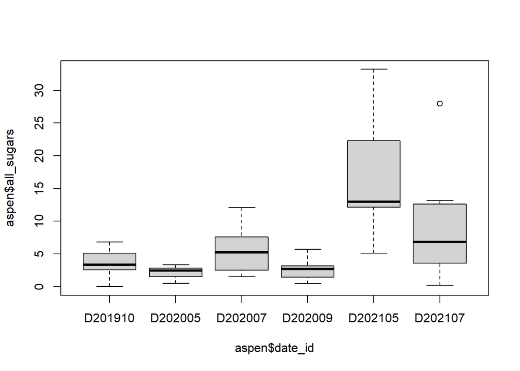

```r
boxplot(aspen$all_sugars ~aspen$date_id)
```

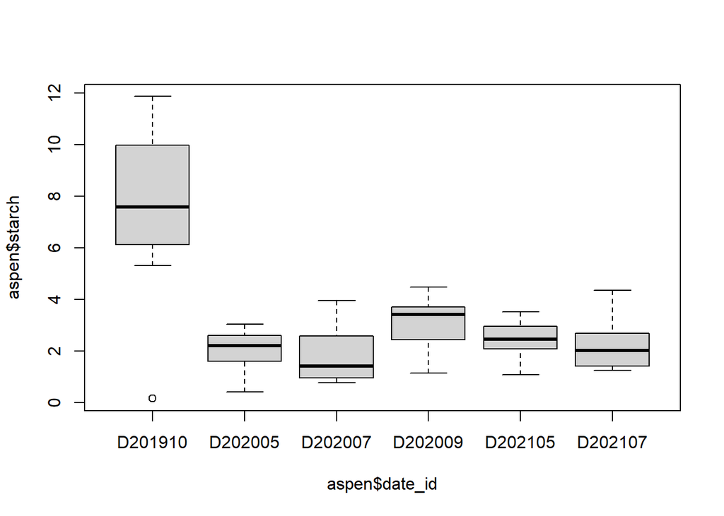

```r
boxplot(aspen$starch~aspen$date_id)
```

# H1.1 Sugars X Phenology

## Results

Testing without considering sampling date as a random factor produced significant differences between groups. However, when fitting to a LMM with sampling date as a random effect, these differences disappeared. The variation is better explained by other environmental differences.

## Analyses

Checking variances between groups:

```r
aspen %>% group_by(phenology) %>%
  summarise(mean = mean(all_sugars, na.rm=TRUE),
            variance = var(all_sugars, na.rm=TRUE))
```

```
## # A tibble: 3 × 3
##   phenology  mean variance
##   <fct>     <dbl>    <dbl>
## 1 LEAF       9.31    87.6
## 2 FULL       7.34    40.3
## 3 SENE       3.01     3.57
```

Very unequal, violates assumption of homoscedaticity.

### Games-Howell Tests

```r
oneway.test(all_sugars ~ phenology, data = aspen)
```

```
##
##  One-way analysis of means (not assuming equal variances)
##
## data:  all_sugars and phenology
## F = 7.8224, num df = 2.000, denom df = 28.678, p-value = 0.001944
```

```r
ght <- as_tibble(games_howell_test(aspen, all_sugars ~ phenology, conf.level = 0.95))
ght
```

```
## # A tibble: 3 × 8
##   .y.        group1 group2 estimate conf.low conf.high p.adj p.adj.signif
##   <chr>      <chr>  <chr>     <dbl>    <dbl>     <dbl> <dbl> <chr>
## 1 all_sugars LEAF   FULL      -1.97    -8.17     4.24  0.719 ns
## 2 all_sugars LEAF   SENE      -6.30   -11.7     -0.892 0.021 *
## 3 all_sugars FULL   SENE      -4.33    -8.07    -0.592 0.021 *
```

Senesced is signficiantly different than leaf out and full leaf, date factors not considered.

#### plot 1.2.1

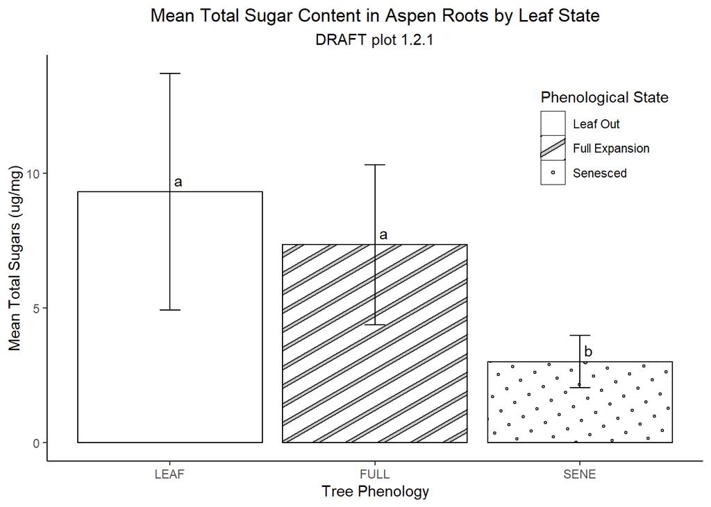

```r
# calculate mean and confidence intervals based off t-distribution
aspen_sugars <- aspen %>%
  group_by(phenology) %>%
  summarise(mean = mean(all_sugars, na.rm=TRUE),
            n = sum(!is.na(all_sugars)),
            SE = SE(all_sugars),
            lower95 = mean - qt(0.975, n-1)*SE,
            upper95 = mean + qt(0.975, n-1)*SE) %>% as_tibble()
aspen_sugars$phenology <- factor(aspen_sugars$phenology, levels = c("LEAF", "FULL", "SENE"))
# plot
p1.2.1 <- ggplot(aspen_sugars, aes(x=phenology, y = mean, pattern=phenology)) +
   geom_col_pattern(fill='white',colour='black',
    pattern_density = 0.2,
    pattern_spacing = 0.04,
    pattern_key_scale_factor = 1) +
  geom_errorbar(aes(ymin=lower95,ymax=upper95), width = 0.1) +
  geom_text(label=c("a","a","b"), hjust = -0.5, vjust=-0.5) +
  theme_classic() +
  theme(plot.title = element_text(hjust=0.5),
        plot.subtitle = element_text(hjust=0.5),
        legend.position = c(0.85, 0.8)) +
  labs(title = "Mean Total Sugar Content in Aspen Roots by Leaf State",
       subtitle = "DRAFT plot 1.2.1",
       x = "Tree Phenology",
       y = "Mean Total Sugars (ug/mg)",
       pattern = c("Phenological State")) +
  scale_pattern_manual(values=c("none","stripe","circle"),
                       labels = c("Leaf Out", "Full Expansion", "Senesced"))
p1.2.1
```

### LMM

Fitting LMM for all_sugars ~ phenology + date_id random effect

```r
sugar_pheno_LMM <- lmer(all_sugars ~ phenology + (1 | date_id:phenology), data=aspen)
emmeans(sugar_pheno_LMM, ~phenology)
```

```
##  phenology emmean   SE   df lower.CL upper.CL
##  LEAF        9.31 4.19 2.97    -4.08     22.7
##  FULL        7.34 4.19 2.97    -6.05     20.7
##  SENE        3.05 4.22 3.06   -10.23     16.3
##
## Degrees-of-freedom method: kenward-roger
## Confidence level used: 0.95
```

#### Testing Model Assumptions

##### Normality of Residuals

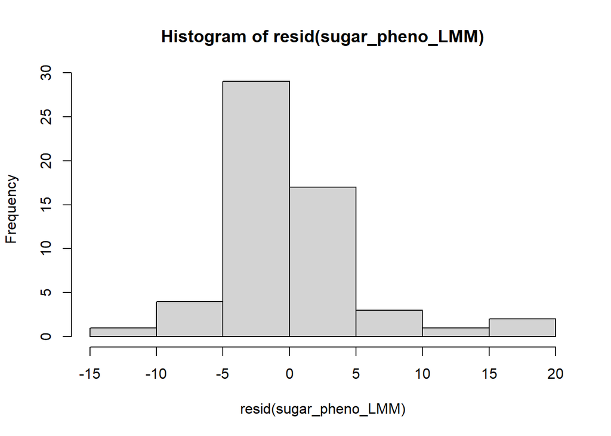

```r
hist(resid(sugar_pheno_LMM))
```

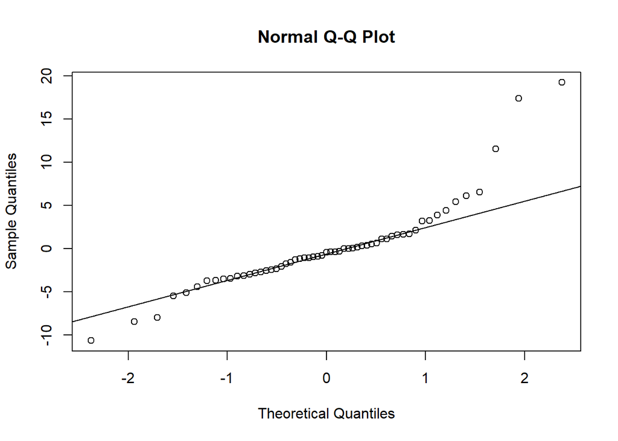

```r
qqnorm(resid(sugar_pheno_LMM))
qqline(resid(sugar_pheno_LMM))
```

Somewhat heavy-tailed, suggests some extreme values to do not fit the model as well, but generally good fit for central values

##### Normality of Random Effect

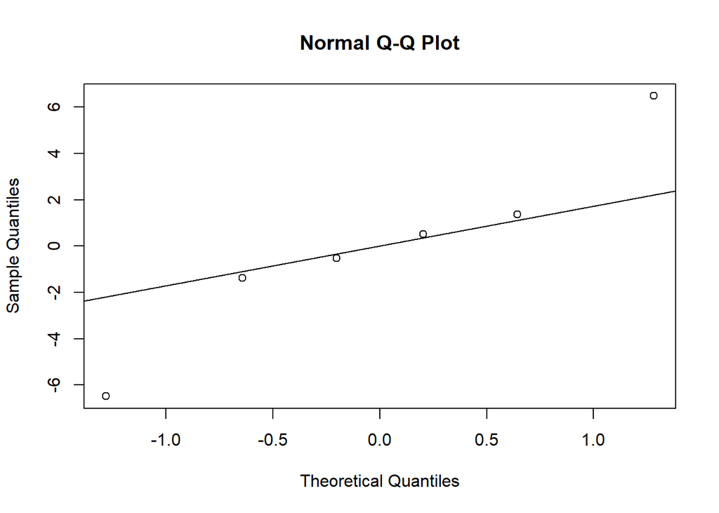

```r
rand_eff <- ranef(sugar_pheno_LMM)$date_id
qqnorm(rand_eff$`(Intercept)`)
qqline(rand_eff$`(Intercept)`) # heavy tailed
```

# H1.2 Starch X Phenology

## Results

Testing without considering sampling date as a random factor produced significant differences between groups. However, when fitting to a LMM with sampling date as a random effect, these differences disappeared. The variation is better explained by other environmental differences.

## Analyses

```r
aspen_starch <- aspen %>%
  group_by(phenology) %>%
  summarise(mean = mean(starch, na.rm=TRUE),
            n = sum(!is.na(starch)),
            SE = SE(starch),
            lower95 = mean - qt(0.975, n-1)*SE,
            upper95 = mean + qt(0.975, n-1)*SE) %>% as_tibble()
aspen_starch
```

```
## # A tibble: 3 × 6
##   phenology  mean     n    SE lower95 upper95
##   <fct>     <dbl> <int> <dbl>   <dbl>   <dbl>
## 1 LEAF       2.21    20 0.188    1.82    2.61
## 2 FULL       2.10    20 0.240    1.59    2.60
## 3 SENE       5.09    17 0.818    3.36    6.83
```

```r
aspen_starch$phenology <- factor(aspen_starch$phenology, levels = c("LEAF", "FULL", "SENE"))
```

Check variances between sample date groups

```r
aspen %>% group_by(phenology, date_id) %>%
  summarise(mean = mean(starch, na.rm=TRUE),
            variance = var(starch, na.rm=TRUE),
            n = sum(!is.na(starch)))
```

```
## # A tibble: 6 × 5
## # Groups:   phenology [3]
##   phenology date_id  mean variance     n
##   <fct>     <fct>   <dbl>    <dbl> <int>
## 1 LEAF      D202005  2.02    0.734    10
## 2 LEAF      D202105  2.41    0.681    10
## 3 FULL      D202007  1.85    1.08     10
## 4 FULL      D202107  2.34    1.22     10
## 5 SENE      D201910  7.42   13.0       8
## 6 SENE      D202009  3.02    1.17      9
```

Very different variance in the D201910 grouping. Violates homoscedasticity

Check variances between phenology groups

```r
aspen %>% group_by(phenology) %>%
  summarise(mean = mean(starch, na.rm=TRUE),
            variance = var(starch, na.rm=TRUE),
            n = sum(!is.na(starch)))
```

```
## # A tibble: 3 × 4
##   phenology  mean variance     n
##   <fct>     <dbl>    <dbl> <int>
## 1 LEAF       2.21    0.710    20
## 2 FULL       2.10    1.15     20
## 3 SENE       5.09   11.4      17
```

SENE is very difference. Violates homoscedasticity.

### Games-Howell Tests

```r
oneway.test(starch ~ phenology, data = aspen)
```

```
##
##  One-way analysis of means (not assuming equal variances)
##
## data:  starch and phenology
## F = 6.1131, num df = 2.000, denom df = 30.301, p-value = 0.005884
```

```r
ght <- as_tibble(games_howell_test(aspen, starch ~ phenology, conf.level = 0.95))
ght
```

```
## # A tibble: 3 × 8
##   .y.    group1 group2 estimate conf.low conf.high p.adj p.adj.signif
##   <chr>  <chr>  <chr>     <dbl>    <dbl>     <dbl> <dbl> <chr>
## 1 starch LEAF   FULL     -0.116   -0.862     0.631 0.924 ns
## 2 starch LEAF   SENE      2.88     0.732     5.03  0.008 **
## 3 starch FULL   SENE      2.99     0.826     5.16  0.006 **
```

#### plot 1.2.2

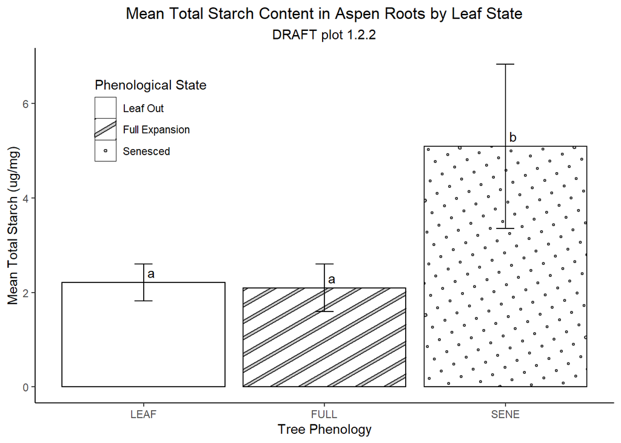

```r
p1.2.2 <- ggplot(aspen_starch, aes(x=phenology, y = mean, pattern=phenology)) +
   geom_col_pattern(fill='white',colour='black',
    pattern_density = 0.2,
    pattern_spacing = 0.04,
    pattern_key_scale_factor = 1) +
  geom_errorbar(aes(ymin=lower95,ymax=upper95), width = 0.1) +
  geom_text(label=c("a","a","b"), hjust = -0.5, vjust=-0.5) +
  theme_classic() +
  theme(plot.title = element_text(hjust=0.5),
        plot.subtitle = element_text(hjust=0.5),
        legend.position = c(0.2, 0.8)) +
  labs(title = "Mean Total Starch Content in Aspen Roots by Leaf State",
       subtitle = "DRAFT plot 1.2.2",
       x = "Tree Phenology",
       y = "Mean Total Starch (ug/mg)",
       pattern = c("Phenological State")) +
  scale_pattern_manual(values=c("none","stripe","circle"),
                       labels = c("Leaf Out", "Full Expansion", "Senesced"))
p1.2.2
```

95% cofidence intervals. Significance markings based of GH tests.

Exploration of effects suggest these effects are not consistent between the different sampling dates. Likely if sampling date is accounted for as a random effect, this result will be minimized.

### LMM

Fitting LMM for **starch = phenology (fixed effect) + date_id (random effect)**

```r
starch_pheno_LMM <- lmer(starch ~ phenology + (1 | date_id:phenology), data=aspen)
emmeans(starch_pheno_LMM, ~phenology)
```

```
##  phenology emmean   SE   df lower.CL upper.CL
##  LEAF        2.21 1.27 2.97    -1.85     6.27
##  FULL        2.10 1.27 2.97    -1.96     6.15
##  SENE        5.21 1.28 3.06     1.19     9.23
##
## Degrees-of-freedom method: kenward-roger
## Confidence level used: 0.95
```

# H1.3 TOC X Phenology

## Results

Phenology was not found to be a good predictor of TOC.

## Analyses

### Exploratory Graphics

Check within-group variance

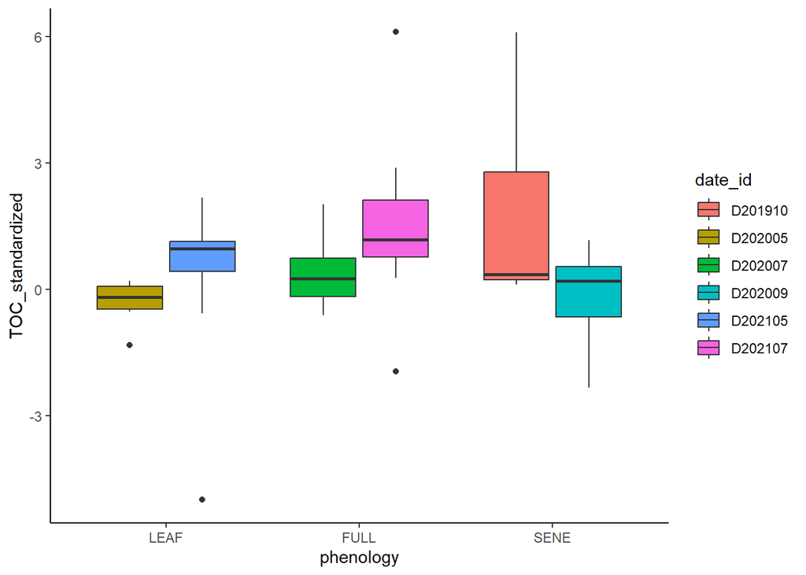

```r
ggplot(data=aspen, aes(x=phenology, y=TOC_standardized, fill=date_id)) +
  geom_boxplot() +
  theme_classic()
```

Normality within phenologies?

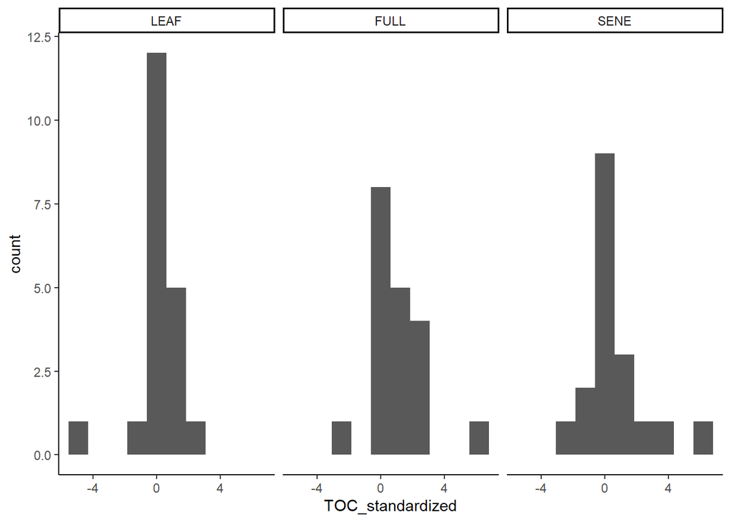

```r
ggplot(data=aspen, aes(x=TOC_standardized)) +
  geom_histogram(bins = 10) +
  facet_wrap(~phenology) +
  theme_classic() # not terrible
```

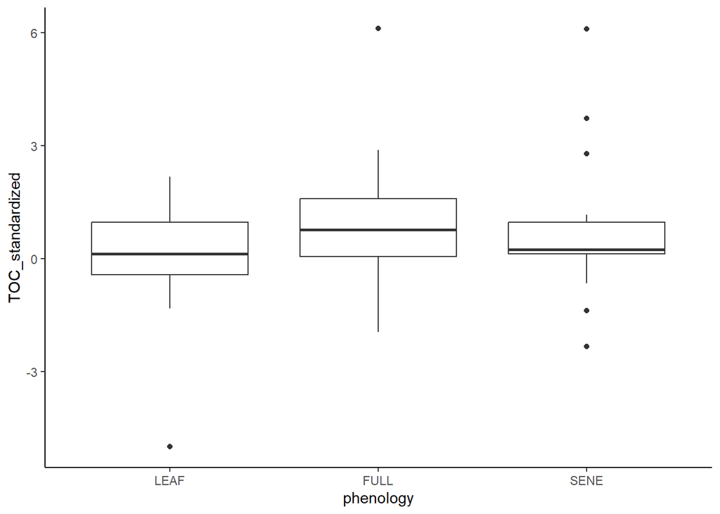

```r
# variance within phenologies?
ggplot(data=aspen, aes(x=phenology, y=TOC_standardized)) +
  geom_boxplot() +
  theme_classic() # not terrible, SENE somewhat different.
```

### LMM

```r
TOC_pheno_LMM <- lmer((TOC_standardized) ~ phenology + (1 | date_id:phenology), data=aspen)
TOC_pheno_emm <- emmeans(TOC_pheno_LMM, ~phenology)
TOC_pheno_emm
```

```
##  phenology emmean    SE  df lower.CL upper.CL
##  LEAF       0.012 0.640 2.9    -2.06     2.09
##  FULL       0.971 0.645 3.0    -1.08     3.03
##  SENE       0.744 0.651 3.1    -1.29     2.78
##
## Degrees-of-freedom method: kenward-roger
## Results are given on the ( (not the response) scale.
## Confidence level used: 0.95
```

#### Testing Model Assumptions

##### Homoscedasticity

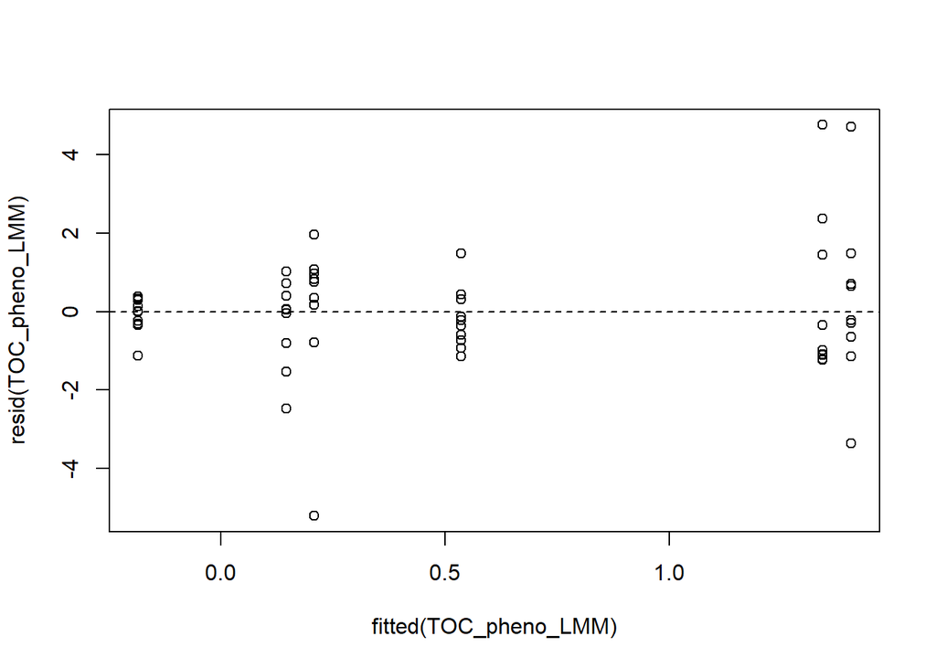

```r
plot(resid(TOC_pheno_LMM)~fitted(TOC_pheno_LMM)) # somewhat wedge-shaped
abline(h=0, lty=2)
```

```r
leveneTest(resid(TOC_pheno_LMM),TOC_pheno_LMM@frame$date_id) # homogenous
```

```
## Levene's Test for Homogeneity of Variance (center = median)
##       Df F value Pr(>F)
## group  5  1.1123 0.3656
##       51
```

##### Normality of Residual

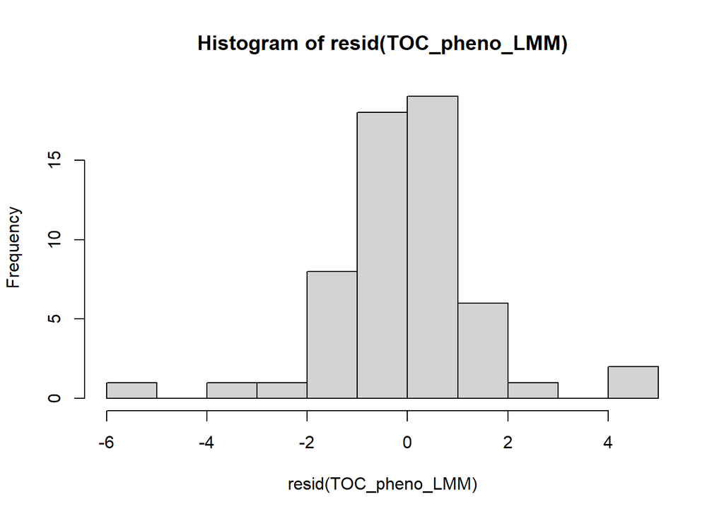

```r
hist(resid(TOC_pheno_LMM), breaks=10) # about right
```

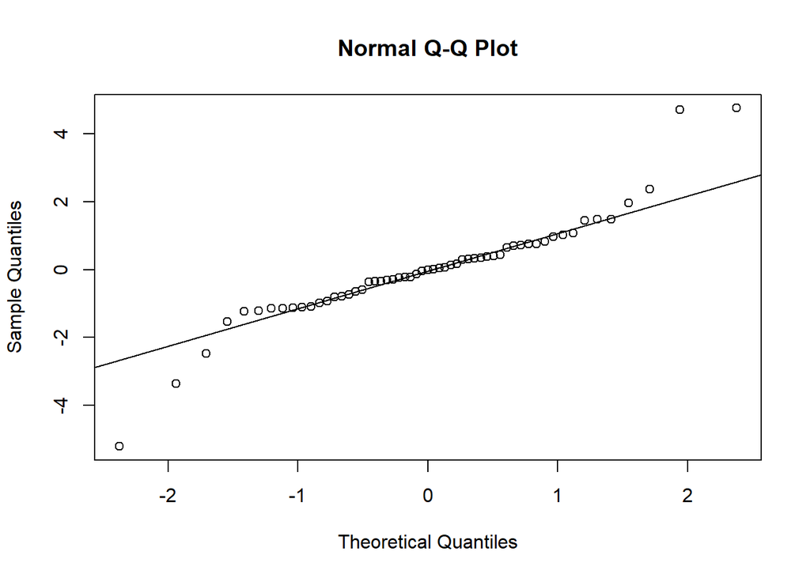

```r
qqnorm(resid(TOC_pheno_LMM))
qqline(resid(TOC_pheno_LMM)) # heavy tailed
```

##### Normality of Random Effect

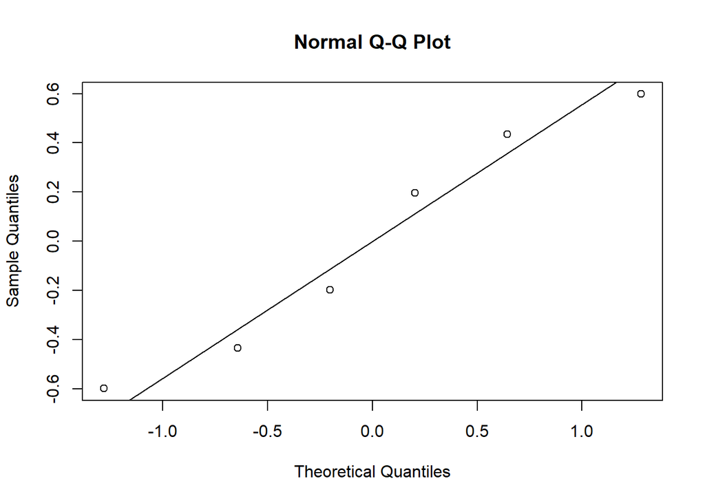

```r
rand_eff <- ranef(TOC_pheno_LMM)$date_id
qqnorm(rand_eff$`(Intercept)`)
qqline(rand_eff$`(Intercept)`) # heavy tailed
```

### ANOVA table

```r
anova(TOC_pheno_LMM)
```

```
## Analysis of Variance Table
##           npar Sum Sq Mean Sq F value
## phenology    2 3.0325  1.5162  0.6095
```

Not a significant predictor of TOC.